# Forecast daily bike rental demand using time series models

# Task Five: Fit and forecast time series data using ARIMA models

####Arima stands for Autoregressive Integrated Moving Average

```r
bikeArima <- auto.arima(cleanMA10)
bikeArima
```

```
## Series: cleanMA10
## ARIMA(1,2,1)
##
## Coefficients:
##          ar1      ma1
##       0.4063  -0.9875
## s.e.  0.0355   0.0079
##
## sigma^2 = 13893:  log likelihood = -4456.15
## AIC=8918.31   AICc=8918.34   BIC=8932.05
```

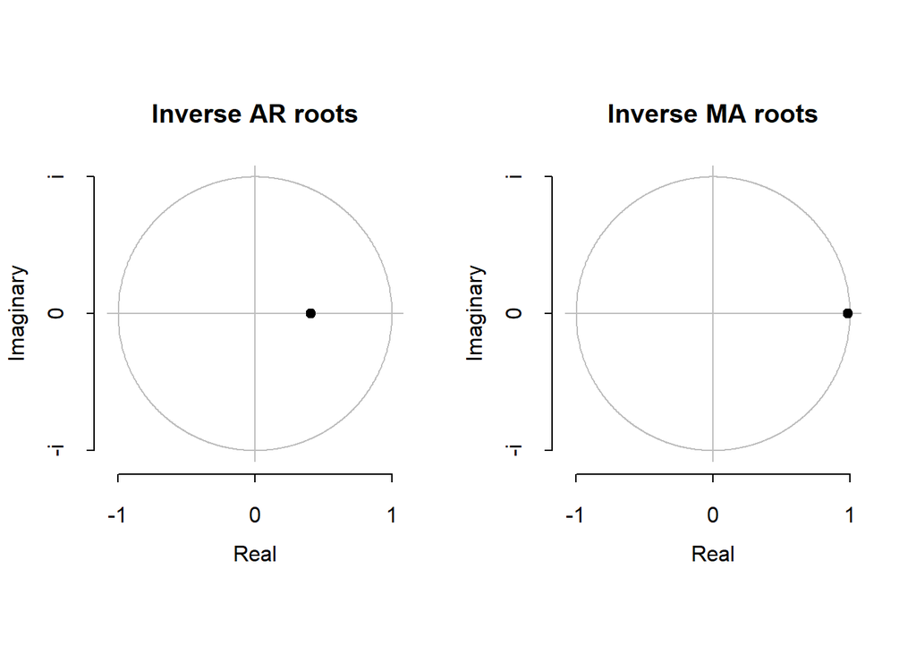

```r
plot(bikeArima)
```

[output not shown]

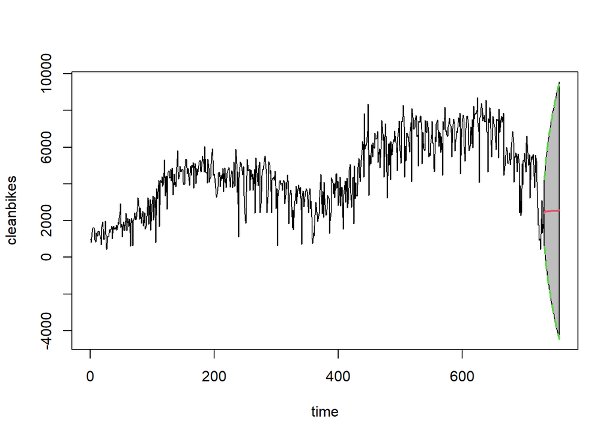

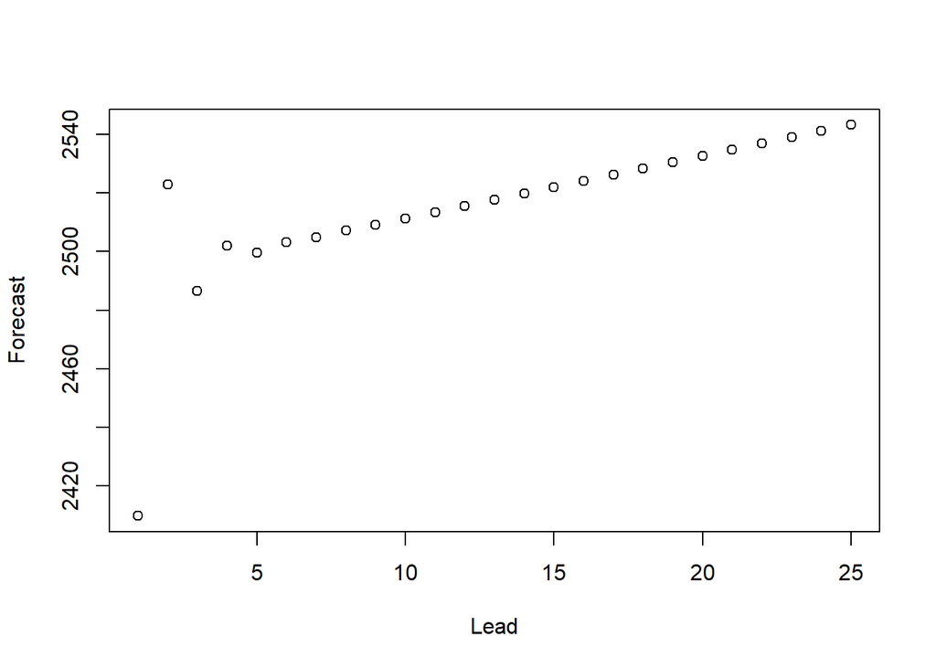

```r
fit <- arima(cleanbikes, order=c(1,2,1))

forecastBikes <- predict(bikeArima, n.ahead = 25)

plot(forecast(fit,25))
```

# Task Six: Findings and Conclusions

Through this process it can be seen that there is a positive correlation between the months in the years and the number of bikes that are rented.

Further research that could be conducted is to examine trends in holiday rentals and potential analysis on hourly use of bikes.Data also pointed towards most of the bike rentals being made between late Spring, Summer, and early Fall seasons.

Thank you for reading!